# Lab6

## Fit your model the evaluation data and compare performance

1. Now used your final model to predict on the other dataset (eval.data.csv)

```r
eel_data <- read_csv(here::here("labs", "data", "eel.eval.data.csv")) %>%
  mutate(Angaus_obs = as.factor(Angaus_obs),
         Method = as.factor(Method))

eval_predict_xgb = predict(xgb_fit, eel_data) %>%  #get testing prediction
  bind_cols(eel_data)
```

2. How does your model perform on this data?

```r
accuracy(eval_predict_xgb, truth = Angaus_obs, estimate = .pred_class)
```

```
## # A tibble: 1 × 3
##   .metric  .estimator .estimate
##   <chr>    <chr>          <dbl>
## 1 accuracy binary         0.842
```

3. How do your results compare to those of Elith et al.?

The results of the Elith et al. indicated that the roc_auc (Area under the receiver operating characteristic curve) was 0.858. We got similar results.

- Use {vip} to compare variable importance

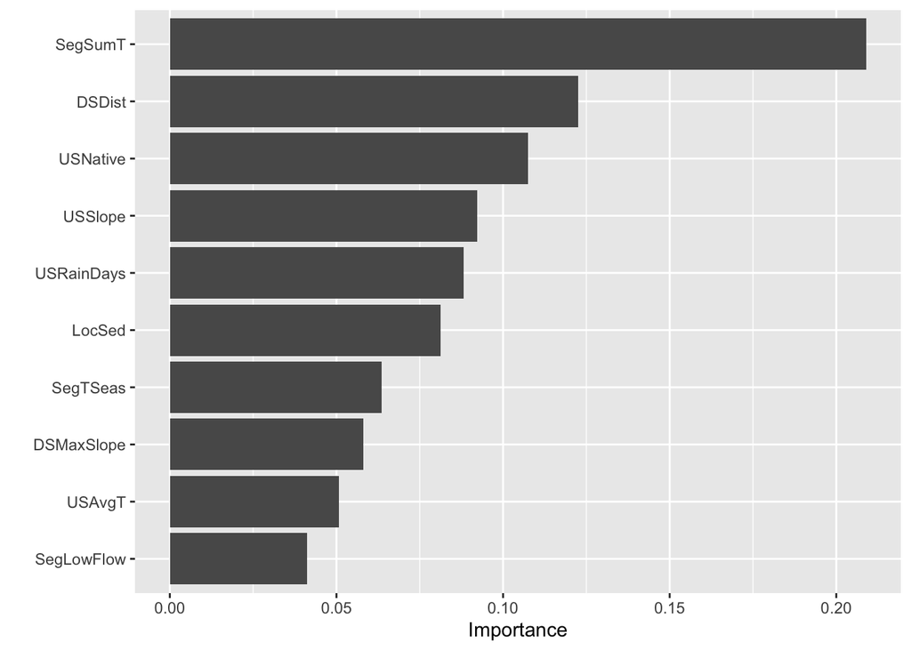

```r
vip::vip(xgb_fit)
```

- What do your variable importance results tell you about the distribution of this eel species?